# Project 2: Data Mining, Classification, Prediction

### Cluster Analysis

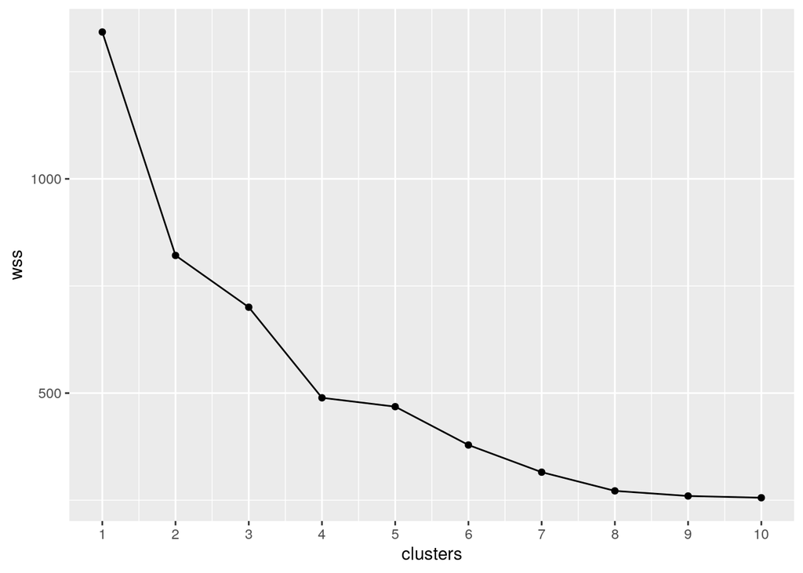

```r
library(cluster)

## set up the wss graph with kmeans.  empty vector wss
wss <- vector()
## function that goes from one to ten to test for possible k
## from 1 to 10
for (i in 1:10) {
    ## remove the Type and Window from the dataframe since they
    ## are categorical variables then pass it to kmeans
    temp <- glass %>% select(-(Type)) %>% select(-Window) %>%
        kmeans(i)
    wss[i] <- temp$tot.withinss
}
## plot the whole thing
ggplot() + geom_point(aes(x = 1:10, y = wss)) + geom_path(aes(x = 1:10,
    y = wss)) + xlab("clusters") + scale_x_continuous(breaks = 1:10)
```

Using the older method of the WSS graph for determining k, it is not completely clear how many clusters there should be. The “elbow” looks like it could be at 4 though it is also possible that it could be 7 since there is a continued sharp decline and then a rapid change in direction. Given that, I will also, use the sillhouette method.

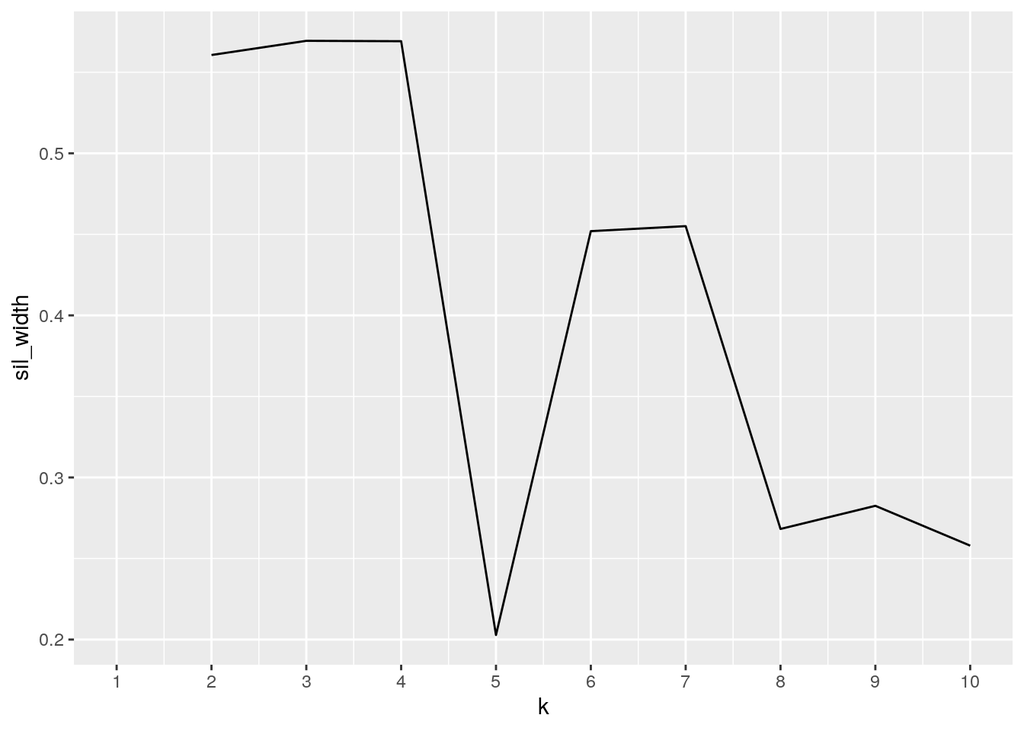

```r
clust_dat <- glass %>% select(-(Type)) %>% select(-Window)
sil_width <- vector()  #empty vector to hold mean sil width
for (i in 2:10) {
    kms <- kmeans(clust_dat, centers = i)  #compute k-means solution
    sil <- silhouette(kms$cluster, dist(clust_dat))  #get sil widths
    sil_width[i] <- mean(sil[, 3])  #take averages (higher is better)
}
ggplot() + geom_line(aes(x = 1:10, y = sil_width)) + scale_x_continuous(name = "k",
    breaks = 1:10)
```

For comparison, I am going to run clustering with both kmeans and with the pam clustering.